# Cidades com Tarifa Zero no Brasil e os Movimentos Sociais de 2013

Thais Pereira

## **Introdução**

Essa é uma análise produzida para o meu mestrado em Ciência Política na USP, a respeito das cidades com tarifa zero no Brasil. Foram pesquisados os movimentos sociais que surgiram em meados de 2013, na época das Jornadas de Junho, muitos deles fizeram páginas no facebook. Em levantamento próprio, fiz uma lista com todos os movimentos que tinha no seu nome Passe Livre ou Tarifa Zero, além de informações como a cidade de origem, a data de surgimento e o número de likes da página. Com isso foi possível produzir um mapa contendo a localização desses movimentos e também uma tabela com suas informações básicas.

A seguir, apresento primeiramente um mapa mostrando apenas as cidades com tarifa zero, depois um mapa interativo que mostra a localização de cidades que atualmente possuem tarifa zero, de acordo com o levantamento de [Daniel Santini](https://docs.google.com/spreadsheets/d/1FFgkyuQEeYYBgk5kWC1P9HKZzlECBS4H/edit?gid=647725414#gid=647725414), e a localização dos movimentos sociais da época das jornadas de junho. A maioria deles não existem mais, no entanto é possível interagir com o mapa e ver a proximidade entre uma cidade que tinha um movimento pró passe livre e uma cidade que atualmente tem passe livre.

## **1. Cidades com tarifa zero no Brasil**

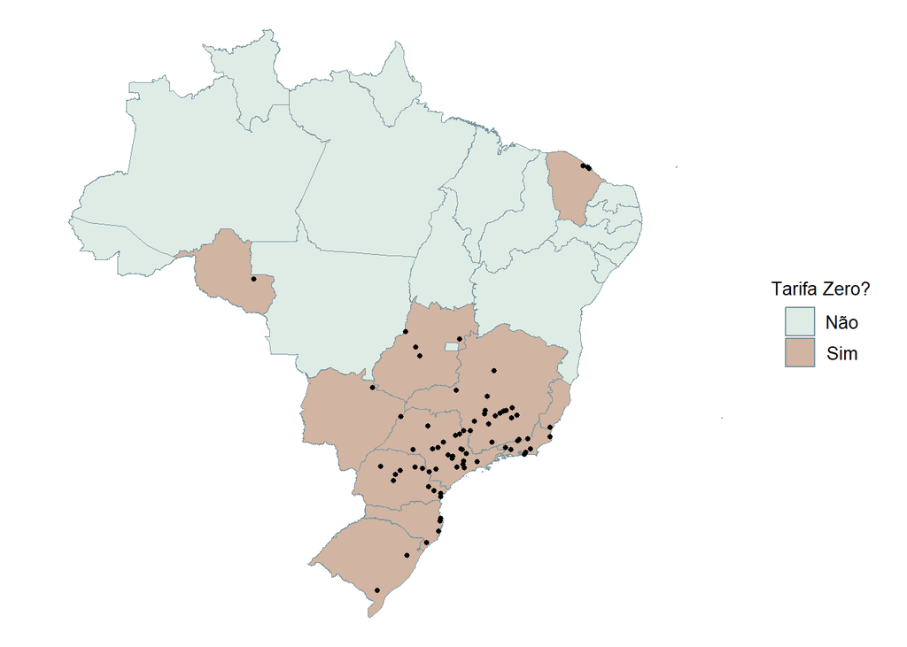

```r
library("tidyverse")
library("knitr")
library("readxl")
library("geobr")
library("sf")
library("ggplot2")
library("reactable")
library("leaflet")
library("kableExtra")

# dados de cidades com tarifa zero + movimentos sociais

file1 <- "https://raw.githubusercontent.com/thais01fernandes/mestrado_usp/main/dados/banco_completo"
banco_completo <- read_delim(file1, delim = ",",
                        locale = locale(encoding='UTF-8')) %>% select(-1) %>%
  rename(CodMun = cod_munic,
         cod_uf = uf_x)


mov_passe_livre <- tibble(CodMun=c(3550308, 4205407, 4209102, 3136702, 3543402, 2507507, 2914802, 3304557, 3549904, 3302205, 3143302, 2111300,  1302603, 3170206, 3539806,5002704, 3518800, 2513703, 2408102, 2704302, 3548500, 4204202, 2927408, 2513851, 3522208, 3520400, 1501402, 5103403,
3106200, 4314407, 2304400, 1200401, 3525300, 4113700, 3303807, 3304201, 3516309,  3503208),
        nome_movi_passe_livre=c("Passe Livre São Paulo", "Passe Livre Floripa", "Passe Livre Joinville", "Passe Livre Juiz de Fora", "Passe Livre Ribeirão Preto", "Passe Livre João Pessoa", "Passe Livre Itabuna", "Passe Livre Rio de Janeiro", "Passe Livre São José dos Campos", "Passe Livre Itaperuna", "Passe Livre Montes Claros", "Passe Livre Manaus", "Passe Livre Maranhão", "Passe Livre Uberlândia", "Passe Livre Poá", "Passe Livre Mato Grosso do Sul", "Passe Livre Guarulhos", "Passe Livre Santa Rita", "Passe Livre Natal", "Passe Livre Maceió", "Passe Livre Santos", "Passe Livre Chapecó", "Passe Livre Salvador", "Passe Livre Região Grande ABC", "Passe Livre Itapecerica da Serra", "Passe Livre Ilhabela", "Passe Livre Belém","Passe Livre Cuiabá", "Passe Livre Belo Horizonte", "Passe Livre Pelotas", "Passe Livre Fortaleza", "Passe Livre Acre", "Passe Livre Jaú", "Passe Livre Londrina", "Passe Livre Paraty", "Passe Livre Resende", "Passe Livre Francisco Morato", "Passe Livre Araraquara"),
 data_origem_pl = c(2011, 2011, 2011, 2012, 2012, 2012, 2013, 2013, 2013, 2013, 2013, 2013, 2013, 2013, 2013, 2013, 2013, 2013, 2013, 2013, 2013, 2013, 2013, 2013, 2013, 2014, 2014, 2014, 2015, 2015, 2015, 2016, 2016, 2016, 2017, 2017, 2018, 2018),
 numero_curtidas_pl = c(301055, 8199, 5637, 201, 3785, 301, 188, 19431, 9850, 318, 84, 1387, 180, 74, 468, 177, 3928, 1218, 626, 150, 745, 50, 5431, 2153, 63,  43, 1356, 287, 6030, 538, 222, 579, 605, 640, 71, 62, 397, 40))

mov_tarifa_zero <- tibble(CodMun = c(2927408,2606200, 2800308, 2913606, 3106200, 4209102, 4106902, 3516200, 3303500, 3506003, 4202404, 3531803),
                          nome_movi_tarifa_zero = c("Tarifa Zero Salvador", "Tarifa Zero Goiânia", "Tarifa Zero Aracaju", "Tarifa Zero Ilhéus", "Tarifa Zero BH", "Tarifa Zero Joinville", "Tarifa Zero Curitiba", "Tarifa Zero Franca", "Tarifa Zero Nova Iguaçu", "Tarifa Zero Bauru", "Tarifa Zero Blumenau",  "Tarifa Zero de Monte Mor"),
                          data_origem_tf = c(2003, 2011, 2013, 2013, 2013, 2013, 2014, 2014, 2015, 2015, 2016, 2016),
                          numero_curtidas_tf = c(2610, 1544, 43, 27, 21438, 473, 1073, 305, 106, 387, 528, 23))

banco_completo_6 <- banco_completo %>%
  left_join(mov_passe_livre, by = "CodMun") %>%
  left_join(mov_tarifa_zero, by = "CodMun")


# dados para o mapa


# Download dos Estados e Municípios:

muni_geobr_1 <- read_municipality(code_muni="all", year=2018, showProgress = F)

geo_ufs <- read_state(code_state = 'all', year = 2018, showProgress = F)

# Estados:

  ffpt_uf <- banco_completo_6 %>%
  select(cod_uf,tarifa_zero) %>%
  distinct() %>%
  rename(code_state=cod_uf)

  geo_ufs_2 <- geo_ufs  %>%
  left_join(ffpt_uf, by = c("code_state"))

  # Convertendo dados_mapa para um objeto sf

geo_ufs_2 <- st_as_sf(geo_ufs_2)

# municipios:

  ffpt_muni <- banco_completo_6  %>%
  rename(code_muni= CodMun) %>%
  select(code_muni,tarifa_zero) %>%
  distinct()


  # camada cidades com tarifa_zero

  muni_geobr_4 <- muni_geobr_1 %>%
  left_join(ffpt_muni, by = c("code_muni")) %>%
  filter(tarifa_zero == "sim") %>%
  rename(`Cidades com Tarifa Zero` = name_muni)

  # Convertendo dados_mapa para um objeto sf

  muni_geobr_4 <- st_as_sf(muni_geobr_4)


  muni_geobr_4 <- muni_geobr_4 %>% mutate(centroid = st_centroid(geom))


geo_ufs_2 %>%
ggplot() +
geom_sf(aes(geometry = geom,
           fill = as.character(tarifa_zero)), color = "#7a959e") +
geom_point(data = muni_geobr_4, aes(x = st_coordinates(centroid)[,1], y = st_coordinates(centroid)[,2]), size = 1, color = "black") +
theme_void()+
scale_fill_manual(name = "Tarifa Zero?", values = c("#dfece6", "#d1b4a2"), labels = c("Não", "Sim")) +
theme(legend.position = "right",
      legend.text = element_text(family = "Lora", size = 10, hjust = 0.5, vjust = 0.5, colour = "black"),
      legend.title = element_text(family = "Lora", size = 10, hjust = 0.5, colour = "black"))
```

## **2. Cidades com tarifa zero e Movimentos Sociais**

```r
# tabela com ícones


tibble("An icon like this:" = "",
       "equals to" = c("Tarifa Zero Movements",
                        "Cities with Tarifa Zero")) %>%
  kbl(booktabs = T,
      align = "cl") %>%
  kable_paper(full_width = F,  html_font = "Cambria") %>%
    column_spec(1, image = spec_image(c("https://img.icons8.com/dusk/64/000000/strike.png", "https://img.icons8.com/ios-filled/50/000000/bus.png"), 80,80))
```

| An icon like this: | equals to |
| --- | --- |
|  | Tarifa Zero Movements |
|  | Cities with Tarifa Zero |

```r
# Primeiro precisamos dos dados de latitude e longitude das cidades analisadas.
urlfile <- "https://raw.githubusercontent.com/kelvins/Municipios-Brasileiros/master/csv/municipios.csv"
cities_lat_lng <- read.csv(urlfile,encoding = "UTF-8")
# é necessário se certificar que o código de cada cidade estará em formato de texto, para o que a função left_join funcione.


cities_lat_lng$codigo_ibge <- as.double(cities_lat_lng$codigo_ibge)

ffpt_muni_5 <- banco_completo_6 %>% rename(codigo_ibge = CodMun) %>%
  left_join(cities_lat_lng, by = "codigo_ibge")


ffpt_muni_6 <- banco_completo_6 %>% rename(codigo_ibge = CodMun) %>%
  left_join(cities_lat_lng, by = "codigo_ibge")

tarifa_zero <- ffpt_muni_5 %>% filter(tarifa_zero == "sim") %>% select(latitude, longitude, nome)

passe_livre <- ffpt_muni_6 %>% select(latitude, longitude, nome_movi_passe_livre) %>%
  filter(!is.na(nome_movi_passe_livre))

movi_tarifa_zero <- ffpt_muni_6 %>% select(latitude, longitude, nome_movi_tarifa_zero) %>%
  filter(!is.na(nome_movi_tarifa_zero))

# mapa:

###icone:

onibus <- makeIcon(
  iconUrl = "https://img.icons8.com/ios-filled/50/000000/bus.png",
  iconWidth = 15, iconHeight = 15)

movimentos <- makeIcon(
  iconUrl = "https://img.icons8.com/dusk/64/000000/strike.png",
  iconWidth = 20, iconHeight = 20)



 leaflet(height=550, width=800) %>%
  addTiles() %>%
  addMarkers(data = tarifa_zero,
             label = ~nome,
             icon = onibus,
         #   clusterOptions = markerClusterOptions(),
             popup= paste("<b> Cidade com Tarifa Zero: </b>", tarifa_zero$nome,"<br>")) %>%
  addMarkers(data = passe_livre,
             label = ~nome_movi_passe_livre,
             icon = movimentos,
           # clusterOptions = markerClusterOptions(),
             popup= paste("<b> Nome do Movimento: </b>", passe_livre$nome_movi_passe_livre,"<br>")) %>%
    addMarkers(data = movi_tarifa_zero,
             label = ~nome_movi_tarifa_zero,
              icon = movimentos,
           #  clusterOptions = markerClusterOptions(),
             popup= paste("<b> Nome do Movimento: </b>", movi_tarifa_zero$nome_movi_tarifa_zero,"<br>"))
```

[interactive chart not shown]

## **3. Tabela com os movimentos sociais**

```r
# organizando os dados

tbl_2 <- banco_completo_6 %>%
  select(nome_movi_passe_livre, data_origem_pl, numero_curtidas_pl) %>%
  filter(!is.na(nome_movi_passe_livre)) %>%
  rename(nome_movi = nome_movi_passe_livre, data_origem = data_origem_pl, numero_curtidas = numero_curtidas_pl)



tbl_3 <- banco_completo_6 %>%
  select(nome_movi_tarifa_zero, data_origem_tf, numero_curtidas_tf) %>%
  filter(!is.na(nome_movi_tarifa_zero)) %>%
  rename(nome_movi = nome_movi_tarifa_zero, data_origem = data_origem_tf, numero_curtidas = numero_curtidas_tf)


  tbl_4 <- tbl_2 %>% full_join(tbl_3, by = c("nome_movi", "data_origem", "numero_curtidas"))


# tabela

      tbl_4 %>%
      reactable(defaultPageSize = 7,
      outlined = T,
      defaultColDef = colDef(
      align = "center",
      headerStyle = list(background = "#d1b4a2")),
      columns = list(
      data_origem = colDef("Date of Origin", minWidth = 100),
      numero_curtidas = colDef("Number of Likes", minWidth = 100),
      nome_movi = colDef("Name of Movement", minWidth = 110)))
```

| Name of Movement | Date of Origin | Number of Likes |
| --- | --- | --- |
| Passe Livre Acre | 2016 | 579 |
| Passe Livre Maranhão | 2013 | 180 |
| Passe Livre Belém | 2014 | 1356 |
| Passe Livre Manaus | 2013 | 1387 |
| Passe Livre Fortaleza | 2015 | 222 |
| Passe Livre Natal | 2013 | 626 |
| Passe Livre João Pessoa | 2012 | 301 |
| Passe Livre Santa Rita | 2013 | 1218 |
| Passe Livre Região Grande ABC | 2013 | 2153 |
| Passe Livre Maceió | 2013 | 150 |

[output cut: 40 more lines]

A work by [Thais Pereira](https://github.com/thais01fernandes)

*thais.fp.pessoal@gmail.com*